## Assignment 11

#### Due Friday, November 20, 11:59 PM CT

### Haoxuan Lu

```r
vb_team <- read_csv("../../data/volleyball-team-2019.csv")
vb_match <- read_csv("../../data/vb-division1-2019-all-matches-corrected.csv") %>%
  mutate(index = row_number()) %>%
  select(index,everything())
```

### 1

Multiple choice: The least-squares regression line is

1. the line that makes the sum of the squares of the vertical distances of the data points to the line as small as possible
2. the line that best splits the data in half, with half of the points above the line and half below the line
3. the line that makes the correlation of the data as large as possible.
4. all of the above
5. a and b
6. a and c
7. b and c
- a

### 2

> Using the *volleyball-team-2019.csv* data to address this question. Create a plot that displays winning percentage vs. errors per set for the teams in the SEC conference. Include a straight line and a smooth line to the plot. Add descriptive labels to the x-axis and y-axis.

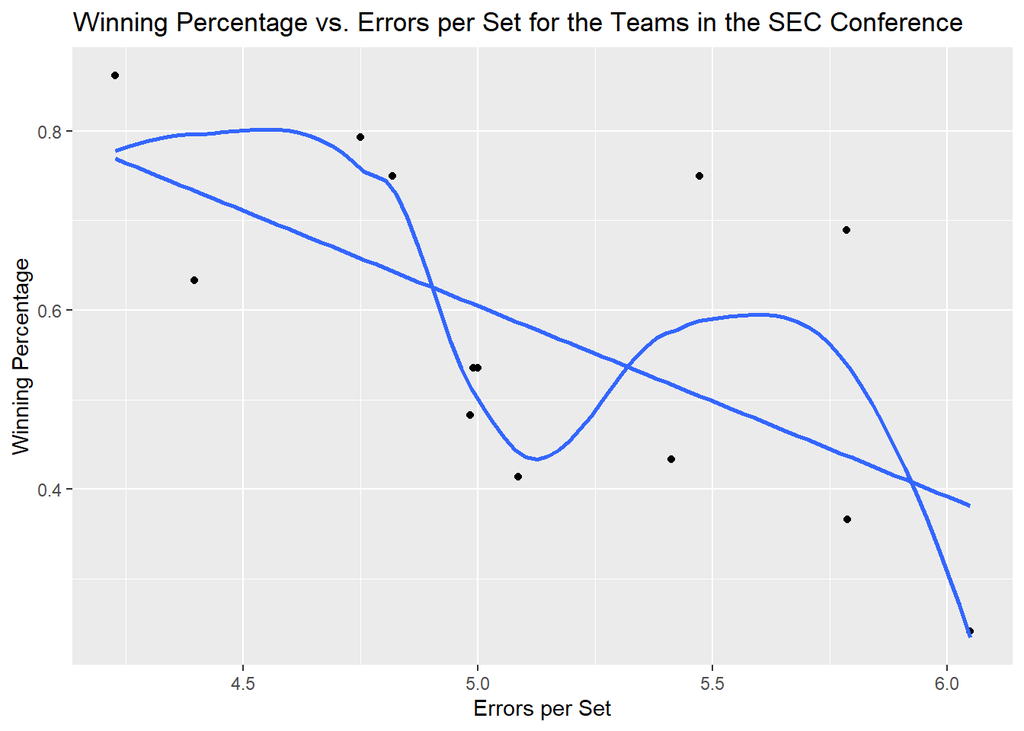

```r
vb_SEC <- vb_team %>%
  filter(Conference == "SEC") %>%
  mutate(error_per_set = Errors / Sets)

ggplot(vb_SEC, aes(x = error_per_set, y = Win_pct)) +
  geom_point() +
  geom_smooth(se = FALSE, method = "lm") +
  geom_smooth(se = FALSE) +
  labs(x = "Errors per Set", y = "Winning Percentage") +
  ggtitle("Winning Percentage vs. Errors per Set for the Teams in the SEC Conference")
```

## 3

> Using your SEC data from question 2, estimate the slope and intercept of a linear model fit to winning percentage as the response variable and errors per set as the explanatory variable. Compute the estimate slope and intercept using the regression formulas below and using the `lm()` function. How do the estimates using the two methods compare?

Slope:
$$\hat{a}_1 = r \frac{s_y}{s_x}$$
where $r$ is the correlation between response variable $y$ and explantory variable $x$, $s_y$ is the standard deviation of $y$, and $s_x$ is the standard deviation of $x$.

Intercept:
$$\hat{a}_0 = \bar{y} - \hat{a}_1\bar{x}$$
where $\bar{y}$ is the sample mean of $y$ and $\bar{x}$ is the sample mean of $x$.

```r
# method 1
win <- pull(vb_SEC, Win_pct)
error <- pull(vb_SEC,error_per_set)
win_sd <- sd(win)
error_sd <- sd(error)
r <- cor(error, win)
slope <- r* win_sd / error_sd
slope
```

```
## [1] -0.2126626
```

```r
win_mean <- mean(win)
error_mean <- mean(error)
intercept <- win_mean - slope * error_mean
intercept
```

```
## [1] 1.667985
```

```r
# method 2
coef(lm(Win_pct ~ error_per_set, vb_SEC))
```

```
##   (Intercept) error_per_set
##     1.6679851    -0.2126626
```

- The two estimate methods get the same result for slope and intercept.

## 4

> Create a plot that displays winning percentage versus errors per set for the teams in the SEC conference. Add the regression model fit in the previous question (using the `lm()` method) to the plot. You may find `geom_abline()` useful for adding your fit model to the plot. Using this estimated model, predict the winning percentage for an SEC team that makes 4.5 errors per set. Plot this value as a red point on your plot.

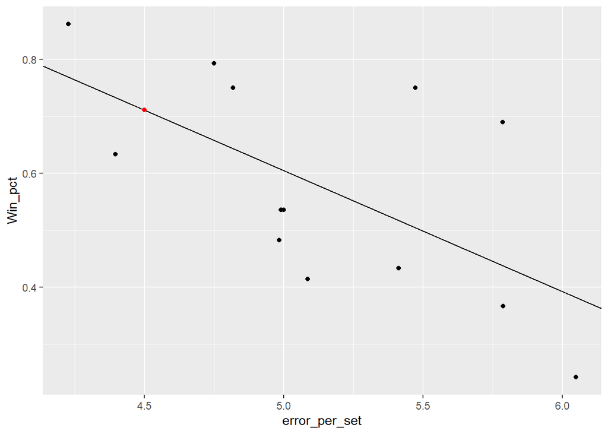

```r
predict <- intercept + slope * 4.5
ggplot(vb_SEC, aes(x = error_per_set, y = Win_pct)) +
  geom_point() +
  geom_abline(slope = slope, intercept = intercept) +
  geom_point(aes(x = 4.5,y = predict), color = "Red")
```

## 5

> Using the *vb-division1-2019-all-matches.csv* data, find the match that occurred between Ole Miss and Alabama on 2019-11-03. Use the data from this match to answer this question.

We would like to fit a logistic model for the Ole Miss - Alabama match. Assume that this match is made up of a series of independent Bernoulli trials, each resulting in a point for one of the teams, until the match is won. Assume also that the chance of a team winning a point is the same whether or not the team is serving and assume that the chance does not depend on the current score of the game.

The Bernoulli probability mass function is
$$f(x | p) = p^x(1-p)^{1-x}$$
where $x$ can equal 0 or 1 ($x=1$ if Ole Miss gets the point and $x=0$ if Alabama gets the point).

If we have $n$ points scored among the two teams, $x_1, \ldots, x_n$, then we can write the likelihood as
$$L(p; x) = \Pi_{i = 1}^np^{x_i}(1-p)^{1-x_i} = p^{\sum x_i}(1-p)^{n-\sum x_i}.$$

A simple model for the probability that Ole Miss with strength $\theta_1$ wins a single point versus Alabama with strength $\theta_2$ is a function of
$$\Delta = \theta_1 - \theta_2$$
where the probability of Ole Miss winning a point is
$$\mathsf{P}(\Delta) = \frac{1}{1 + \mathrm{e}^{-\Delta}}.$$

- The logistic function is a function of the log odds, $\ln(p/(1-p))$, where $p$ is a probability.
  - That is, $\ln(p/(1-p)) = \Delta$.
  - If we solve for $p$ we get the inverse-logistic function (displayed above for $P(\Delta)$).
- In summary, we model the Bernoulli probability $p$ as a function of $\Delta$ (so we can write $p = P(\Delta)$). Ultimately we want the maximum likelihood estimate of $p$ and of $\Delta$.

Here are the steps to address this question.

- Write out the Bernoulli likelihood for the noted Ole Miss vs Alabama match
- Plot the likelihood function for $p$
- Compute the maximum likelihood estimate for $p$ - you can do this mathematically or computationally
- Add a vertical red dashed line on your plot at the maximum likelihood value for $p$
- Compute the maximum likelihood value for $\Delta$ by putting the estimate for $p$ into the log odds formula

```r
vb_match %>%
  filter(date == "2019-11-03" & (team1 == "Alabama" & team2 == "Ole Miss") | (team2 == "Alabama" & team1 == "Ole Miss")) %>%
  summarise(Ole_point = sum(s1_1, s1_2, s1_3, s1_4, s1_5),
            Alabama_point = sum(s2_1, s2_2, s2_3, s2_4, s2_5),
            total = Ole_point + Alabama_point)
```

```
## # A tibble: 1 x 3
##   Ole_point Alabama_point total
##       <dbl>         <dbl> <dbl>
## 1       100           107   207
```

The Bernoulli likelihood for the noted Ole Miss vs Alabama match is
$$\mathsf{L}(\Delta) = P(\Delta)^{100}(1-P(\Delta))^{107}$$

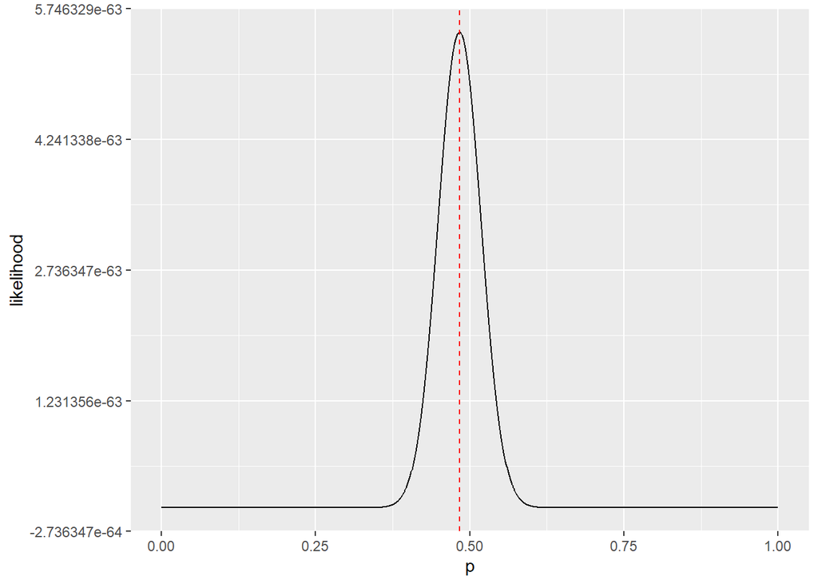

```r
p <- seq(0, 1, by = 0.001)
likelihood = p^100 * (1-p)^107
max_likelihood <- 100 / 207

tibble(likelihood, p) %>%
  ggplot(aes(x = p, y = likelihood)) +
  geom_line() +
  geom_vline(xintercept = max_likelihood, linetype = "dashed", color = "red")
```

```r
max_likelihood
```

```
## [1] 0.4830918
```

```r
delta <- log((100 / 207) / (107 / 207))
delta
```

```
## [1] -0.06765865
```

- The maximum likelihood estimate for $p$ is 100/207 (0.4830918)
- The maximum likelihood value for $\Delta$ is -0.06765865